# Final Project Spring ’19

Asya Kirgiz

April 28, 2019

## Birth Data Description

This data set contains monthly live births in thousands for the United states from year 1948 to 1979:

```r
data(birth,package="astsa")
start(birth)
```

```
## [1] 1948    1
```

```r
end(birth)
```

```
## [1] 1979    1
```

```r
frequency(birth)
```

```
## [1] 12
```

```r
summary(birth)
```

```
##    Min. 1st Qu.  Median    Mean 3rd Qu.    Max.
##   238.0   284.0   310.0   310.9   336.0   399.0
```

Data references: http://www.stat.pitt.edu/stoffer/tsa4/.

## Plots

Plots help you visualize the data and spot any trends:

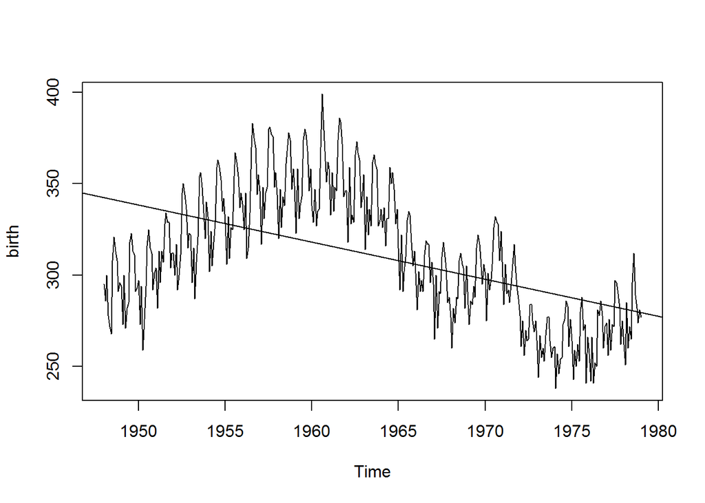

```r
plot(birth)
abline(reg=lm(birth~time(birth)))
```

```r
cycle(birth)
```

```
##      Jan Feb Mar Apr May Jun Jul Aug Sep Oct Nov Dec
## 1948   1   2   3   4   5   6   7   8   9  10  11  12
## 1949   1   2   3   4   5   6   7   8   9  10  11  12
## 1950   1   2   3   4   5   6   7   8   9  10  11  12
## 1951   1   2   3   4   5   6   7   8   9  10  11  12
## 1952   1   2   3   4   5   6   7   8   9  10  11  12
## 1953   1   2   3   4   5   6   7   8   9  10  11  12
## 1954   1   2   3   4   5   6   7   8   9  10  11  12
## 1955   1   2   3   4   5   6   7   8   9  10  11  12
## 1956   1   2   3   4   5   6   7   8   9  10  11  12
## 1957   1   2   3   4   5   6   7   8   9  10  11  12
## 1958   1   2   3   4   5   6   7   8   9  10  11  12
## 1959   1   2   3   4   5   6   7   8   9  10  11  12
## 1960   1   2   3   4   5   6   7   8   9  10  11  12
## 1961   1   2   3   4   5   6   7   8   9  10  11  12
```

[output cut: 18 more lines]

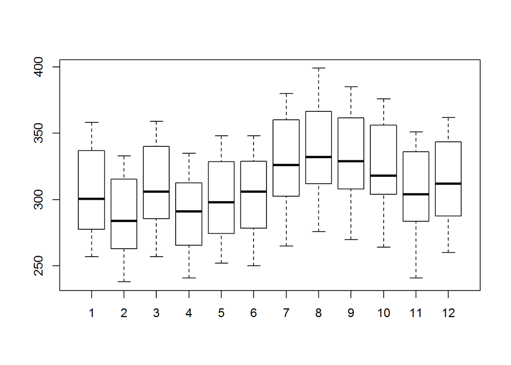

```r
boxplot(birth ~ cycle(birth))
```

## Investigate seasonal patterns in the data

Notice seasonal difference between number of births in Aprils vs. Octobers

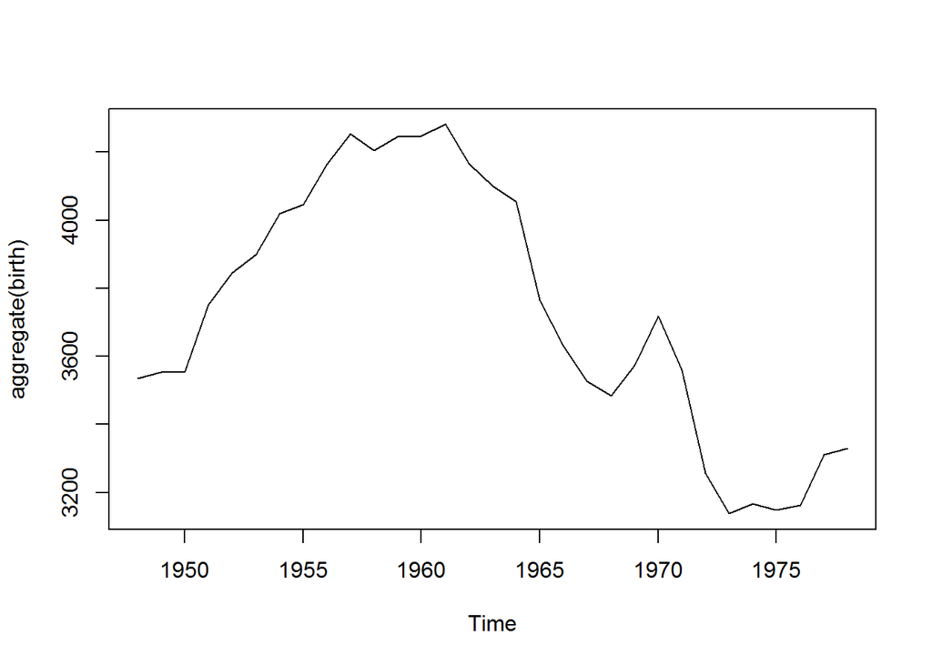

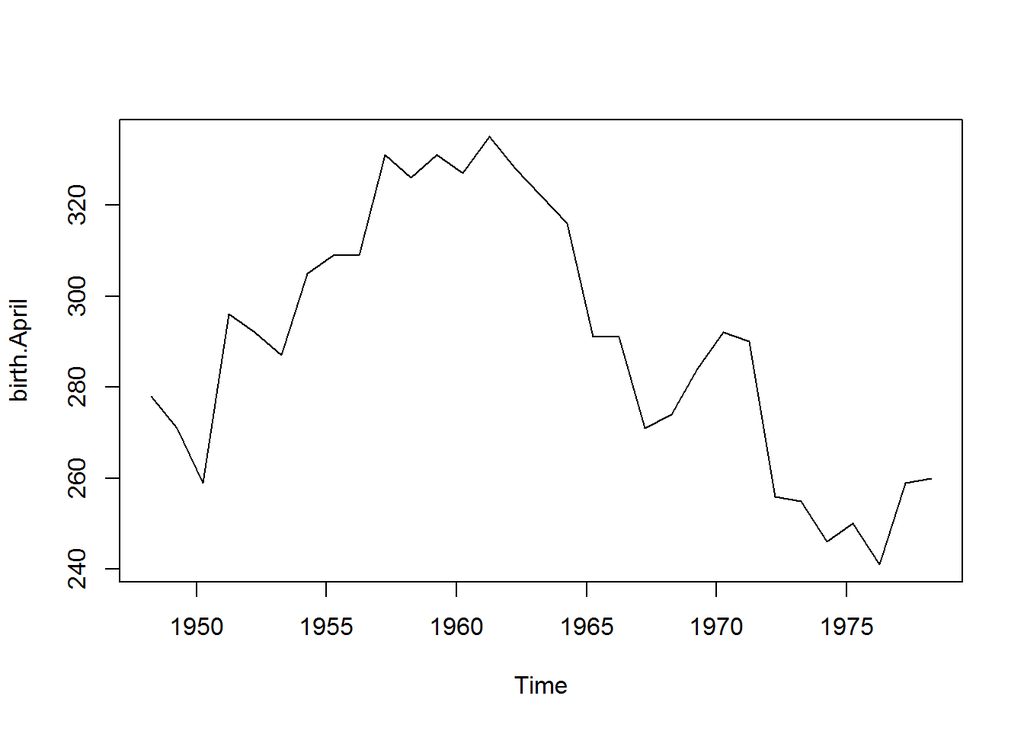

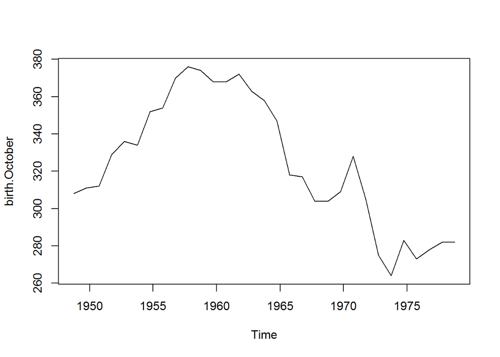

## Decompose using multiplicative model

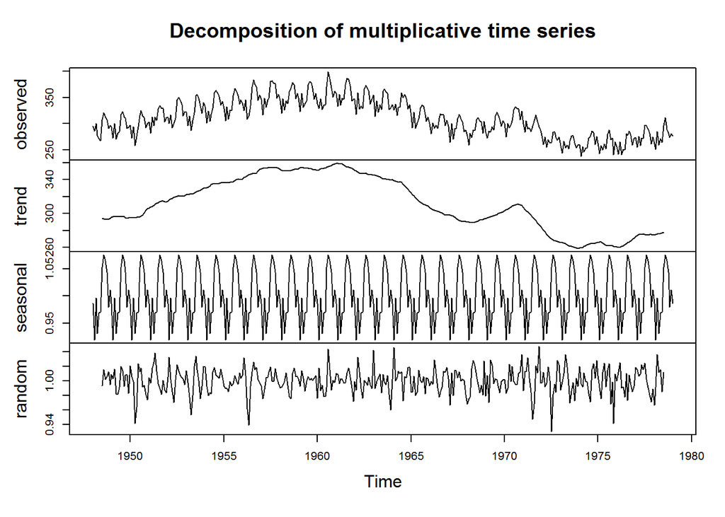

```r
birth.decom <- decompose(birth, type="mult")
plot(birth.decom)
```

The trend over years seem to folow a smoth curve that is showing an upward trend until 1962, then turning and displaying a downward trend until 1975 and then reversing into an upward trend again. These changes in number of births in US could be explained by historical and econamical events. There are clear seasonal variations in the data. The random part of the data does look random.

## Transformation

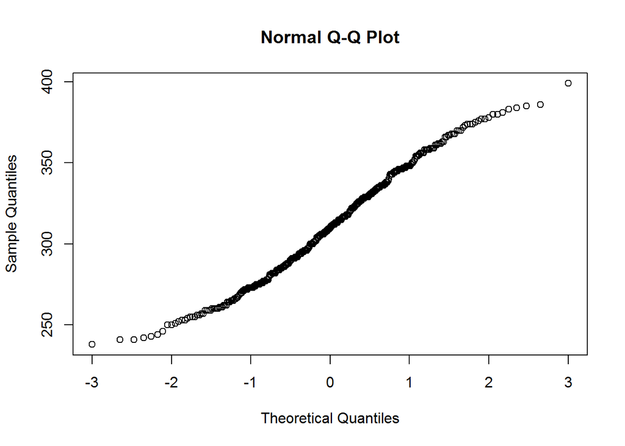

```r
qqnorm(birth)
```

Examining Q-Q norm plot of birth data which looks close to a straight line suggests that the distribution could be reasonably assumed to be normal.

## Autocorrelation for lag 1, lag 2, lag 3

```r
acf(birth)$acf[2]
```

```
## [1] 0.8828933
```

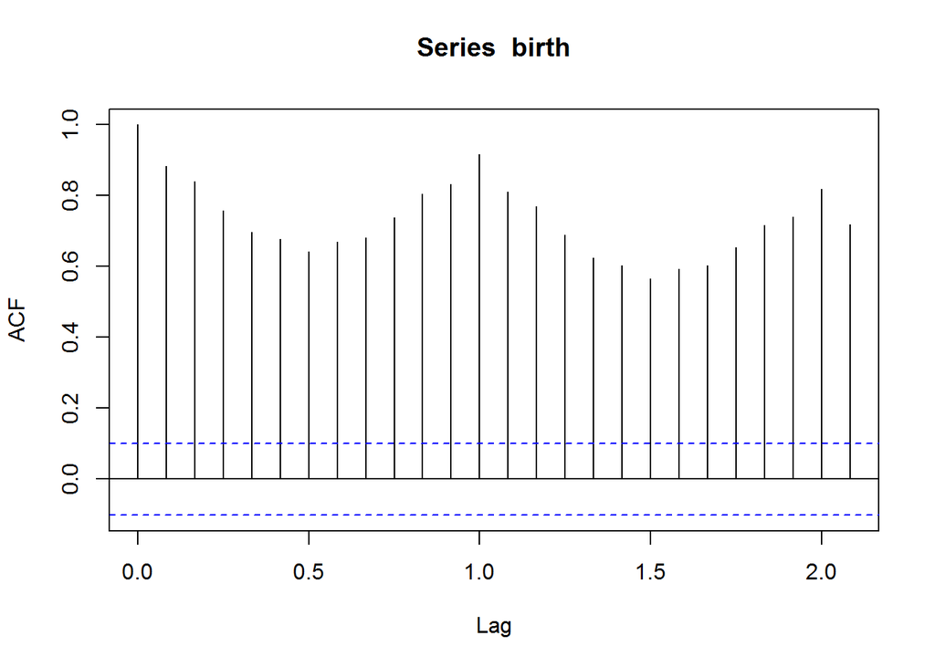

```
## [1] 0.8391203
```

```r
acf(birth)$acf[3]
```

```r
acf(birth)$acf[4]
```

```
## [1] 0.7585455
```

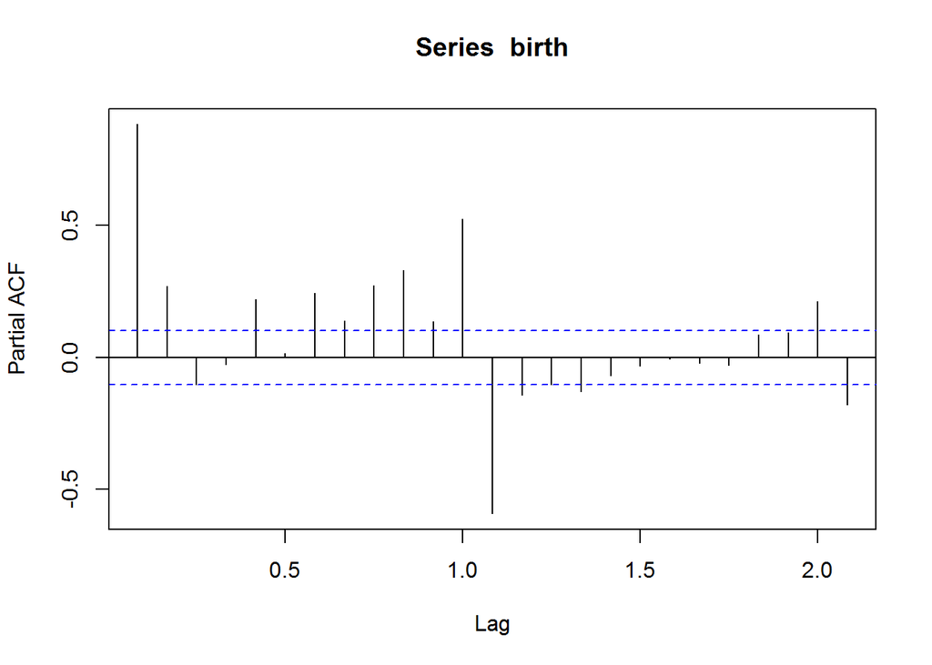

```r
pacf(birth)
```

## Model fitting

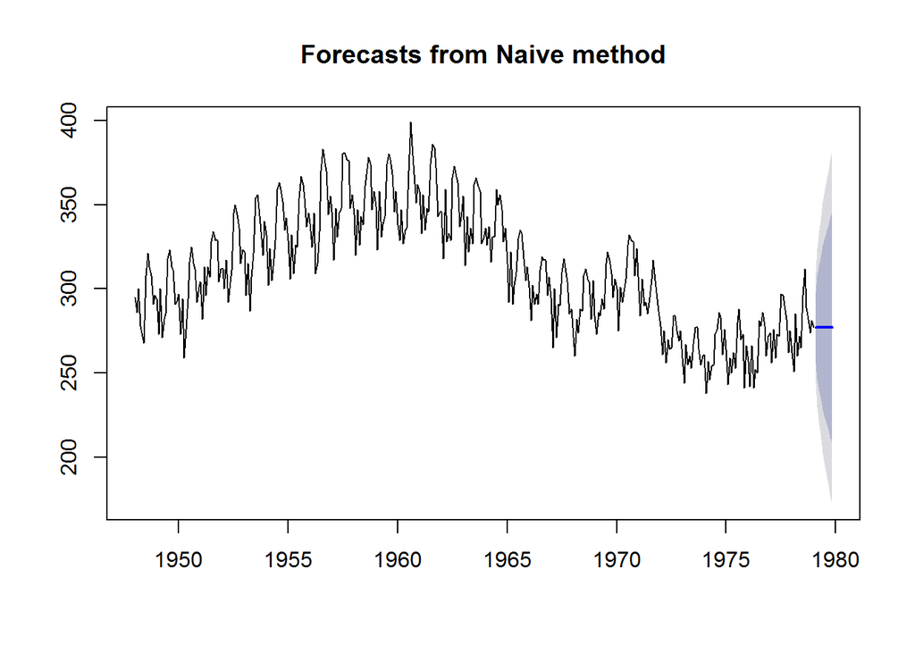

Let’s look at autocorrelation of birth differences from month to month:

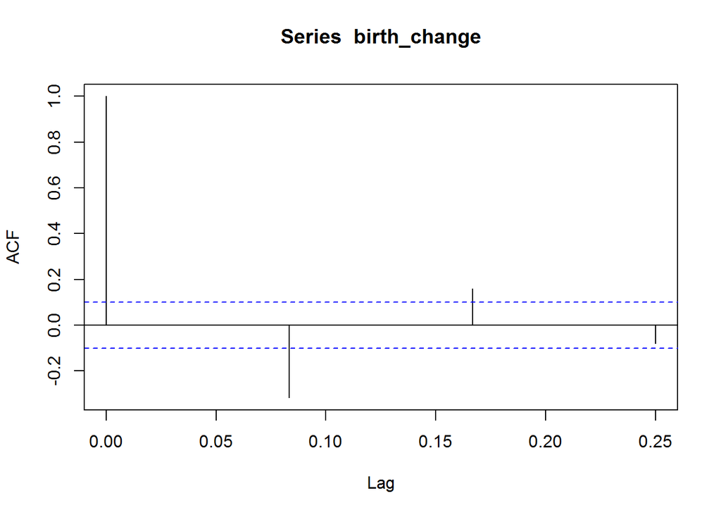

Now, let’s fit a first order moving average model MA_birth_change, a first order auto-regression model AR_birth_change and an ARIMA model.

```r
MA_birth_change <- arima(birth_change, order=c(0,0,1))
AR_birth_change <- arima(birth_change, order=c(1,0,0))
ARIMA_birth_change <- arima(birth_change, order=c(1,1,1))
```

## Evaluate the models

Use residuals to diagnose the models.

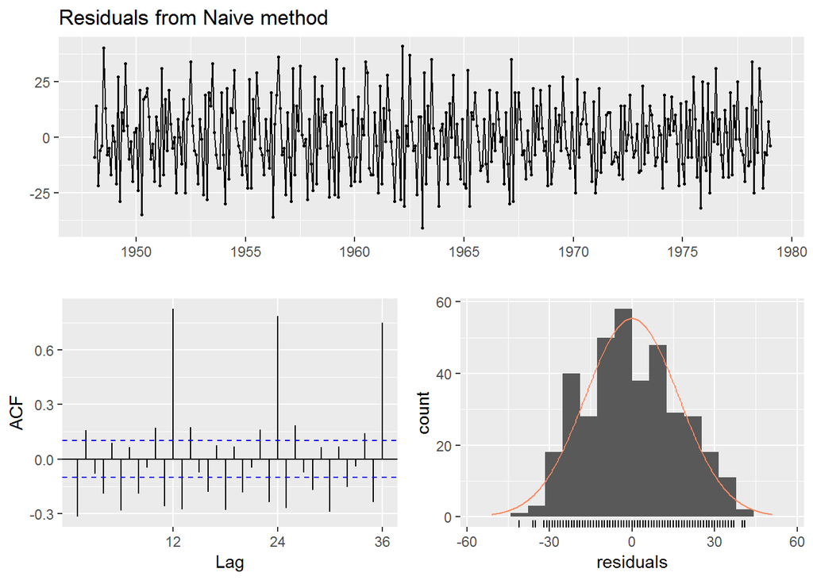

```
##
##  Ljung-Box test
##
## data:  Residuals from Naive method
## Q* = 796.67, df = 24, p-value < 2.2e-16
##
## Model df: 0.   Total lags used: 24
```

```r
checkresiduals(birth_fit)
```

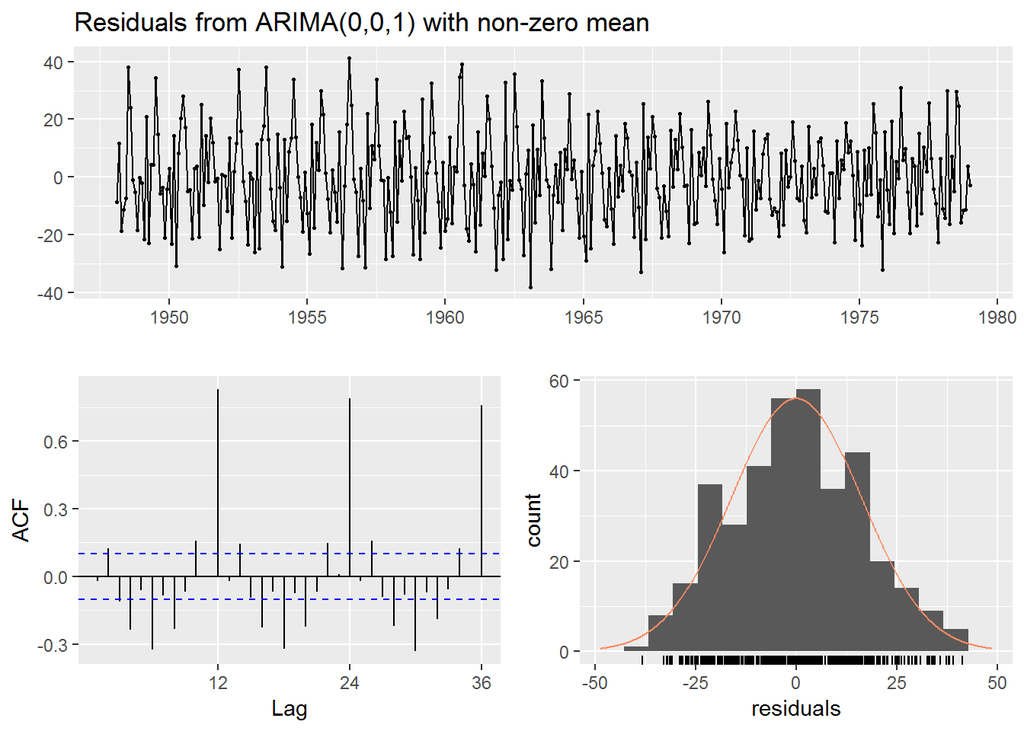

```
##
##  Ljung-Box test
##
## data:  Residuals from ARIMA(0,0,1) with non-zero mean
## Q* = 729.73, df = 22, p-value < 2.2e-16
##
## Model df: 2.   Total lags used: 24
```

```r
checkresiduals(MA_birth_change)
```

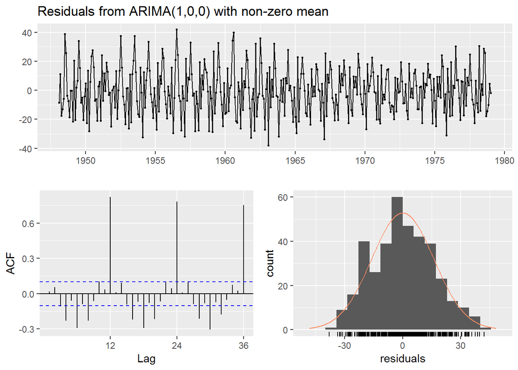

```
##
##  Ljung-Box test
##
## data:  Residuals from ARIMA(1,0,0) with non-zero mean
## Q* = 679.5, df = 22, p-value < 2.2e-16
##
## Model df: 2.   Total lags used: 24
```

```r
checkresiduals(AR_birth_change)
```

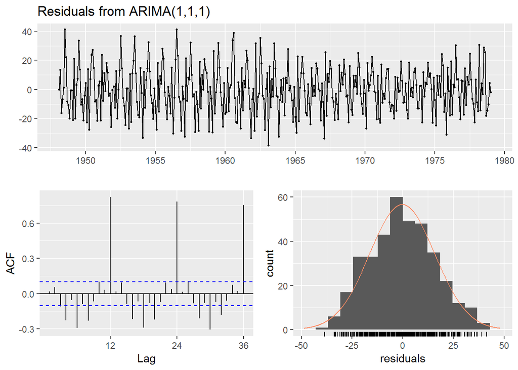

```
##
##  Ljung-Box test
##
## data:  Residuals from ARIMA(1,1,1)
## Q* = 680.46, df = 22, p-value < 2.2e-16
##
## Model df: 2.   Total lags used: 24
```

```r
checkresiduals(ARIMA_birth_change)
```

```r
accuracy(birth_fit)
```

```
##                      ME     RMSE      MAE        MPE     MAPE     MASE
## Training set -0.0483871 16.94885 14.04301 -0.1693737 4.574274 1.431261
##                    ACF1
## Training set -0.3172926
```

```r
accuracy(MA_birth_change)
```

```
##                        ME     RMSE      MAE MPE MAPE      MASE        ACF1
## Training set -0.005704594 16.19384 13.06573 NaN  Inf 0.5715585 -0.02093694
```

```r
accuracy(AR_birth_change)
```

```
##                       ME     RMSE      MAE MPE MAPE      MASE       ACF1
## Training set -0.00635804 16.07219 12.97137 NaN  Inf 0.5674304 0.02001808
```

```r
accuracy(ARIMA_birth_change)
```

```
##                      ME     RMSE      MAE MPE MAPE      MASE      ACF1
## Training set -0.2696036 16.07225 12.99394 NaN  Inf 0.5684178 0.0193071
```

Secondly, use information criterion AIC and BIC to evaluate the models.

```r
AIC(MA_birth_change)
```

```
## [1] 3133.543
```

```r
AIC(AR_birth_change)
```

```
## [1] 3127.951
```

```r
AIC(ARIMA_birth_change)
```

```
## [1] 3127.024
```

```r
BIC(MA_birth_change)
```

```
## [1] 3145.3
```

```r
BIC(AR_birth_change)
```

```
## [1] 3139.708
```

```r
BIC(ARIMA_birth_change)
```

```
## [1] 3138.773
```

The ARIMA_birth_change model has lowest AIC and BIC than others, so we’ll use it for foreasting.

## Forecasting

```r
predict(ARIMA_birth_change, n.ahead = 12)
```

```
## $pred
##              Jan         Feb         Mar         Apr         May
## 1979              1.20687135 -0.43271865  0.08357130 -0.07900307
## 1980 -0.04007354
##              Jun         Jul         Aug         Sep         Oct
## 1979 -0.02781008 -0.04393022 -0.03885416 -0.04045256 -0.03994924
## 1980
##              Nov         Dec
## 1979 -0.04010773 -0.04005782
## 1980
##
## $se
##           Jan      Feb      Mar      Apr      May      Jun      Jul
## 1979          16.11554 16.88263 16.96088 16.96734 16.96838 16.96836
## 1980 16.96839
##           Aug      Sep      Oct      Nov      Dec
## 1979 16.96840 16.96839 16.96839 16.96839 16.96839
## 1980
```

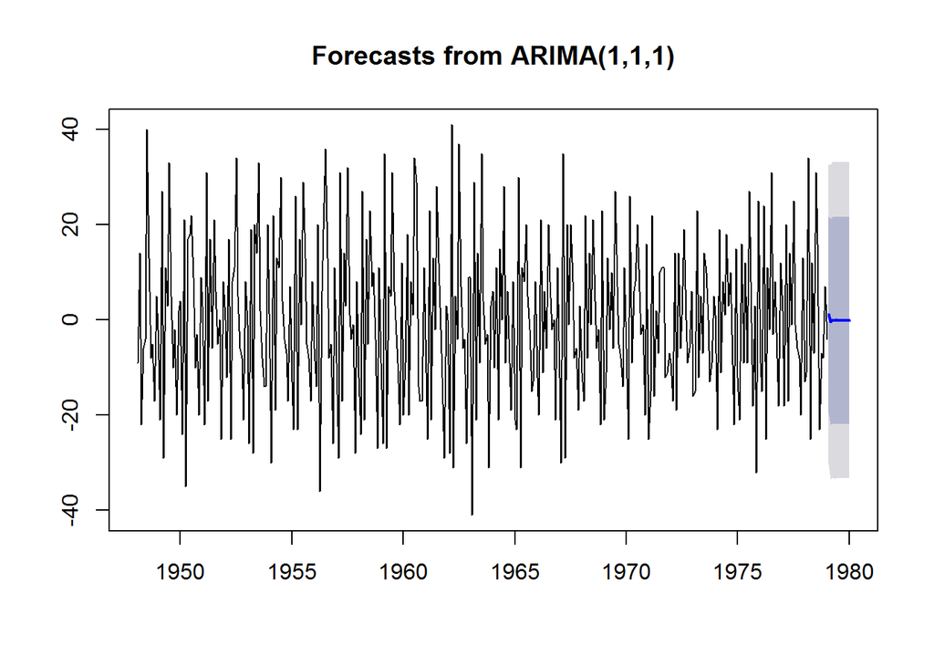

```r
future = forecast(ARIMA_birth_change, h = 12)
plot(future)
```